# Recorded Session: working with JSON and jsonlite

```r
# load necessary packages
library(tidyverse)
library(jsonlite)
library(listviewer)
```

# 1 **How do JSON strings look like anyways?**

Let’s take a look at how a typical JSON file might look like.

```r
# print contents of the JSON file "students_data.json"
cat(paste0(readLines("data/students_data.json", warn=FALSE), collapse="\n"))
```

```
## {
##     "students": [
##         {
##             "id":"014789",
##             "firstname": "Francesco",
##             "lastname": "Danovi"
##         },
##         {
##             "id":"023657",
##             "firstname": "Gabriel",
##             "lastname": "da Silva Zech"
##         }
##     ],
##
##     "teachers": ["Simon Munzer", "Lisa Oswald"],
##
##     "ages_students_teachers": [[23, 24],
##                                [27, 33]],
##
##     "university": {
##         "name": "Hertie School of Governance",
##         "location": "Berlin",
##         "coordinates": [52.51297066351335, 13.389164312650935]
##     }
## }
```

# 2 **Understanding how JSON files are read with `jsonlite`**

First, let’s load the same JSON file with jsonlite’s [`fromJSON()`](https://www.rdocumentation.org/packages/jsonlite/versions/1.7.2/topics/toJSON,%20fromJSON) function.

As you will see, the output features different types of data, such as data frames, vectors, matrices and lists.

```r
json_data <- fromJSON("data/students_data.json")
json_data
```

```
## $students
##       id firstname      lastname
## 1 014789 Francesco        Danovi
## 2 023657   Gabriel da Silva Zech
##
## $teachers
## [1] "Simon Munzer" "Lisa Oswald"
##
## $ages_students_teachers
##      [,1] [,2]
## [1,]   23   24
## [2,]   27   33
##
## $university
## $university$name
## [1] "Hertie School of Governance"
##
## $university$location
## [1] "Berlin"
##
## $university$coordinates
## [1] 52.51297 13.38916
```

## 2.1 Why the different data types? The answer is *simple*

JSON data usually gets converted into **lists** when it is read by `fromJSON()`.

However, **this is not always the case**. Depending on how the JSON data is structured, `fromJSON()` automatically converts the array to other R classes.

This process where JSON arrays automatically get converted from a list into a more specific R class is called **simplification**.

There are **3 types** of JSON arrays that get converted to different R classes by default:

- arrays of **primitives**
- arrays of **objects**
- arrays of **arrays**

*Hint: you can identify `arrays` through blockquotes `[]`.*

Let’s take a closer look at these.

### 2.1.1 R `vectors` are created from JSON `arrays of primitives` (strings, numbers, booleans or null)

The `teachers` element in the JSON file is an **array of primitives**. “Primitives” are either `strings`, `numbers`, `booleans` or `null` values (they are named so because they are the simplest elements available in a programming language).

> “teachers”: [“Simon Munzer”, “Lisa Oswald”]

Why? It has

- `Primitives` i.e. strings separated by commas `,`
- all within blockquotes `[]`

These get converted to a R `vector` by default. See again:

```r
json_data["teachers"] # output is a R vector
```

```
## $teachers
## [1] "Simon Munzer" "Lisa Oswald"
```

### 2.1.2 R `data frames` are created from JSON `arrays of objects` (key-value pairs)

The `students` element in the JSON file is an **array of objects**.

Why? It has

- `Objects` i.e. key-value pairs separated by commas `,`
- within curly brackets `{}` that are also separated by commas `,`
- all within blockquotes `[]`.

These get converted to a R `data frame` by default. See again:

```r
json_data["students"] # output is a R data frame
```

```
## $students
##       id firstname      lastname
## 1 014789 Francesco        Danovi
## 2 023657   Gabriel da Silva Zech
```

### 2.1.3 R `matrices` are created from JSON `arrays of arrays` (equal-length sub-arrays)

The `ages_students_teachers` element in the JSON file is an **array of arrays**.

> “ages_students_teachers”: [[23, 24], [27, 33]]

Why? It has

- `Arrays` i.e. numbers separated by commas `,` within blockquotes `[]`
- next to other **equal length** `arrays` separated by commas `,`
- all within blockquotes `[]`.

These get converted to a R `matrix` by default. See again:

```r
json_data["ages_students_teachers"] # output is a R matrix
```

```
## $ages_students_teachers
##      [,1] [,2]
## [1,]   23   24
## [2,]   27   33
```

## 2.2 How and why to prevent automatic simplification

It is possible, however, to disable this automatic simplification. This can be done by passing `simplifyVector = FALSE` to the `fromJSON()` function.

This will make sure all values are returned as **lists**.

```r
# array of primitives
fromJSON('["Simon Munzer", "Lisa Oswald"]')
```

```
## [1] "Simon Munzer" "Lisa Oswald"
```

```r
fromJSON('["Simon Munzer", "Lisa Oswald"]', simplifyVector = FALSE)
```

```
## [[1]]
## [1] "Simon Munzer"
##
## [[2]]
## [1] "Lisa Oswald"
```

```r
# array of objects
fromJSON('[{ "id":"023657", "name": "Gabriel", "lastname": "da Silva Zech" }]')
```

|  | id | name | lastname |
| --- | --- | --- | --- |
| 1 | 023657 | Gabriel | da Silva Zech |

```r
fromJSON('[{ "id":"023657", "name": "Gabriel", "lastname": "da Silva Zech" }]', simplifyVector = FALSE)
```

```
## [[1]]
## [[1]]$id
## [1] "023657"
##
## [[1]]$name
## [1] "Gabriel"
##
## [[1]]$lastname
## [1] "da Silva Zech"
```

```r
# array of arrays
fromJSON('[[23, 24], [27, 33]]')
```

```
##      [,1] [,2]
## [1,]   23   24
## [2,]   27   33
```

```r
fromJSON('[[23, 24], [27, 33]]', simplifyVector = FALSE)
```

```
## [[1]]
## [[1]][[1]]
## [1] 23
##
## [[1]][[2]]
## [1] 24
##
##
## [[2]]
## [[2]][[1]]
## [1] 27
##
## [[2]][[2]]
## [1] 33
```

**Why is knowing this relevant?**

Having all your data organised in lists instead of a mixture of lists, vectors, data frames and matrices is beneficial because it will allow you to **work more consistently** with a few number of helper functions.

Don’t take my word for it. You can take Hadley Wickham’s, the guy behind tidyverse - it has been [reported](https://themockup.blog/posts/2020-05-22-parsing-json-in-r-with-jsonlite/) that when he works with the jsonlite package, he prefers to read JSON files without simplifying them.

## 2.3 Reading newline-delimited JSON files

A slight variation of the JSON format is the [newline-delimited JSON (aka ndjson)](http://ndjson.org/) format.

In this format, each line is a JSON element in itself. This allows one to read individual elements without having to parse the entire file, which is helpful in certain use cases such as reading log files.

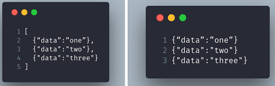

JSON on the left, ndjson on the right (credit: [Jaga Santagostino](https://medium.com/@kandros/newline-delimited-json-is-awesome-8f6259ed4b4b))

This is important to know because `fromJSON()` will through the error `parse error: trailing garbage` when trying to read a ndjson file.

> fromJSON(“data/yelp_academic_dataset_business.json”)

> Error in parse_con(txt, bigint_as_char) : parse error: trailing garbage: true}, “type”: “business”} {“business_id”: “UsFtqoBl7naz8A (right here) ——^

This is where jsonlite’s [`stream_in()`](https://www.rdocumentation.org/packages/jsonlite/versions/1.7.2/topics/stream_in,%20stream_out) function for reading ndjson comes in. It is especially useful because it allows us to read specific lines of a ndjson file without having to parse the entire document.

Let’s use it to read the first 500 lines of a dataset containing information on businesses on the Yelp platform ([source](https://www.kaggle.com/yelp-dataset/yelp-dataset)).

```r
# read the first 500 lines of the ndjson file
yelp_list <- stream_in(textConnection(readLines("data/yelp_academic_dataset_business.json", n=500)), simplifyVector = FALSE)
```

```
##
 Found 500 records...
 Imported 500 records. Simplifying...
```

```r
# alternatively, the code below reads the entire file:
# yelp_list <- stream_in(file("data/yelp_academic_dataset_business.json"), simplifyVector = FALSE)

# print the information for the first business
str(yelp_list[[1]])
```

```
## List of 15
##  $ business_id  : chr "vcNAWiLM4dR7D2nwwJ7nCA"
##  $ full_address : chr "4840 E Indian School Rd\nSte 101\nPhoenix, AZ 85018"
##  $ hours        :List of 5
##   ..$ Tuesday  :List of 2
##   .. ..$ close: chr "17:00"
##   .. ..$ open : chr "08:00"
##   ..$ Friday   :List of 2
##   .. ..$ close: chr "17:00"
##   .. ..$ open : chr "08:00"
##   ..$ Monday   :List of 2
##   .. ..$ close: chr "17:00"
##   .. ..$ open : chr "08:00"
##   ..$ Wednesday:List of 2
##   .. ..$ close: chr "17:00"
##   .. ..$ open : chr "08:00"
##   ..$ Thursday :List of 2
##   .. ..$ close: chr "17:00"
##   .. ..$ open : chr "08:00"
##  $ open         : logi TRUE
##  $ categories   :List of 2
##   ..$ : chr "Doctors"
##   ..$ : chr "Health & Medical"
##  $ city         : chr "Phoenix"
##  $ review_count : int 9
##  $ name         : chr "Eric Goldberg, MD"
##  $ neighborhoods: list()
##  $ longitude    : num -112
##  $ state        : chr "AZ"
##  $ stars        : num 3.5
##  $ latitude     : num 33.5
##  $ attributes   :List of 1
##   ..$ By Appointment Only: logi TRUE
##  $ type         : chr "business"
```

# 3 **Transforming JSON data into tidy data sets**

As explained in [this very helpful tidyr article](https://tidyr.tidyverse.org/articles/rectangle.html), “rectangling is the art and craft of taking a deeply nested list (often sourced from wild caught JSON or XML) and taming it into a tidy data set of rows and columns”.

The most important functions for rectangling are:

- `unnest_longer()` takes each element of a list-column and makes a new **row**
- `unnest_wider()` takes each element of a list-column and makes a new **column**
- `hoist()` is similar to `unnest_wider()` but only plucks out selected components, and can reach down multiple levels

We will go over these in the upcoming live coding session. For now, let’s just run these without further explanation:

```r
yelp_df <- tibble(business_info = yelp_list) %>%
  hoist(business_info,
        "name",
        "city",
        "neighborhood" = list("neighborhoods", 1),
        "hours") %>%
  unnest_longer(hours) %>%
  rename("day" = hours_id) %>%
  unnest_wider(hours) %>%
  select(-business_info)

yelp_df
```

| name | city | neighborhood | close | open | day |
| --- | --- | --- | --- | --- | --- |
| Eric Goldberg, MD | Phoenix | NA | 17:00 | 08:00 | Tuesday |
| Eric Goldberg, MD | Phoenix | NA | 17:00 | 08:00 | Friday |
| Eric Goldberg, MD | Phoenix | NA | 17:00 | 08:00 | Monday |
| Eric Goldberg, MD | Phoenix | NA | 17:00 | 08:00 | Wednesday |
| Eric Goldberg, MD | Phoenix | NA | 17:00 | 08:00 | Thursday |
| Clancy's Pub | Dravosburg | NA | NA | NA | NA |
| Cool Springs Golf Center | Bethel Park | NA | NA | NA | NA |
| Verizon Wireless | Pittsburgh | NA | 21:00 | 10:00 | Monday |
| Verizon Wireless | Pittsburgh | NA | 21:00 | 10:00 | Tuesday |
| Verizon Wireless | Pittsburgh | NA | 21:00 | 10:00 | Friday |

[output cut: 2011 more lines]

# 4 **Exporting data to JSON file with `toJSON()`**

Exporting data to a JSON file is very simple. First we have to transform the data (e.g. the data frame) into a JSON string with [`toJSON()`](https://www.rdocumentation.org/packages/jsonlite/versions/1.7.2/topics/toJSON,%20fromJSON).

```r
# select first row to export
yelp_export <- head(yelp_df, 1)

# create a JSON string
toJSON(yelp_export)
```

```
## [{"name":"Eric Goldberg, MD","city":"Phoenix","close":"17:00","open":"08:00","day":"Tuesday"}]
```

The `toJSON()` function has a bunch of arguments to define how the output should be encoded.

For instance, when the argument `pretty` is set to `True` it adds indentation whitespace to make JSON strings more readable by humans.

```r
toJSON(yelp_export, pretty = T)
```

```
## [
##   {
##     "name": "Eric Goldberg, MD",
##     "city": "Phoenix",
##     "close": "17:00",
##     "open": "08:00",
##     "day": "Tuesday"
##   }
## ]
```

Finally, to save the JSON data to a file, simply use `write()`.

```r
write(toJSON(yelp_export, pretty = T), "data/yelp_export.json")
```

Thats it! More to follow on the live coding session :)

By Gabriel da Silva Zech and Francesco Danovi

*Prepared for Intro to Data Science, taught by Simon Munzert*

*[Hertie School, Berlin](https://www.hertie-school.org/en/)*